# Revision data updated

We check the new data given by the company

```python
# Load packages
import nltk # imports the natural language toolkit
nltk.download('punkt')
nltk.download('stopwords')
import pandas as pd
import numpy  as np
import matplotlib.pyplot as plt
import string
import re
from collections import Counter
from nltk.stem import PorterStemmer
from nltk.util import ngrams
from pylab import rcParams
from wordcloud import WordCloud
from sklearn.feature_extraction.text import CountVectorizer
import plotly.express as px
import nltk
from wordcloud import WordCloud
import os
```

```python
from data_exploring.data_exploring_functions import *
```

```python
# Load preprocessed data from surveys
base_datapath = 'C:\\Users\\sapmn3\\Database\\OFFCORSS\\data\\data_clean'

load_file = 'offcorss_surveys'
load_path = os.path.join(base_datapath, load_file + '.csv')
data_surveys = pd.read_csv(load_path)
data_surveys = data_surveys.drop(columns=['Unnamed: 0'])
data_surveys.head()
```

|  | Survey Date | Name | User Id | Email | Rating | Classification | Comment | Response Date | Requester | Ticket Id | Brand | Group | Assignee | Satisfaction | processed comment |
| --- | --- | --- | --- | --- | --- | --- | --- | --- | --- | --- | --- | --- | --- | --- | --- |
| 0 | 2020-08-10 | Johanna Vargas T | 4.008424e+11 | vhannyt@gmail.com | 7.0 | passive | NaN | 2020-08-10 11:38 | NaN | NaN | NaN | NaN | NaN | NaN | NaN |
| 1 | 2020-08-10 | Maria Carolina Parra Rincón | 4.009328e+11 | mariacarolinaparrar@gmail.com | 1.0 | detractor | Atender a las reclamaciones a tiempo para evit... | 2020-08-10 11:59 | NaN | NaN | NaN | NaN | NaN | bad | atender a las reclamaciones a tiempo para evit... |
| 2 | 2020-08-10 | Luz Marina González Pulido | 4.006469e+11 | 14a793667beb4637bc67b25241ee1150@ct.vtex.com.br | 0.0 | detractor | No leen con atención, por favor dictar capacit... | 2020-08-10 12:11 | NaN | NaN | NaN | NaN | NaN | bad | no leen con atención , por favor dictar capaci... |
| 3 | 2020-08-10 | Devolución de producto | 4.011302e+11 | paolaga@gmail.com | 3.0 | detractor | Se debe poder hacer cambios en tiends fisicas.... | 2020-08-10 12:32 | NaN | NaN | NaN | NaN | NaN | bad | se debe poder hacer cambios en tienda fisicas ... |
| 4 | 2020-08-10 | Devolución de producto | 4.013074e+11 | leonlobozharick@gmail.com | 10.0 | promoter | NaN | 2020-08-10 12:37 | NaN | NaN | NaN | NaN | NaN | good | NaN |

## Confirm the dates for all surveys provided:

Defining the dates of the information to assess whether covers 2019 and 2020

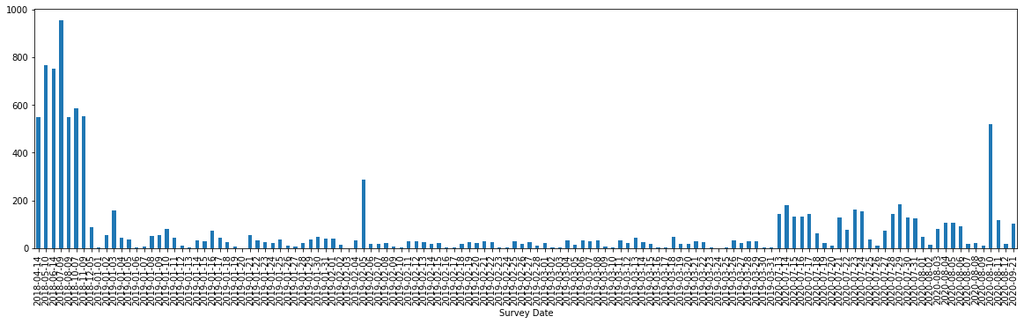

```python
data_responses = data_surveys.copy()
dates_responses = data_responses.groupby(['Survey Date'])['Satisfaction'].count()

fig = plt.figure(figsize=(20,5))

dates_responses.plot.bar()
plt.show()
```

```
[26, 35, 25, 31, 59, 33, 26, 27, 1, 1, 1, 1, 1, 1, 1, 1, 1, 1, 1, 1, 1, 1, 1, 1, 1, 1, 1, 1, 1, 1, 1, 1, 1, 1, 1, 1, 1, 1, 1, 1, 1, 1, 1, 1, 1, 1, 1, 1, 1, 1, 1, 1, 1, 1, 1, 1, 1, 1, 1, 1, 1, 1, 1, 1, 1, 1, 1, 1, 1, 1, 1, 1, 1, 1, 1, 1, 1, 1, 1, 1, 1, 1, 1, 1, 1, 1, 1, 1, 1, 1, 1, 1, 1, 1, 1, 1, 1, …
```

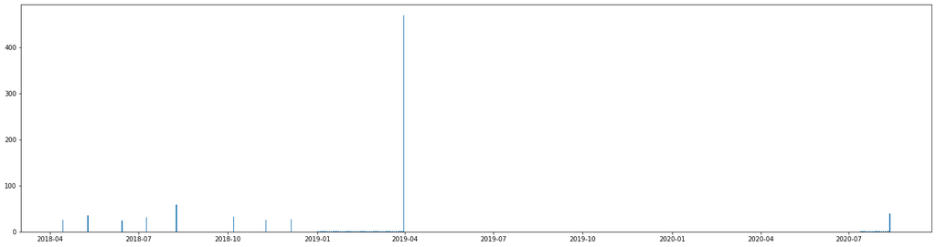

```python
# There are days missing:

comm_day = pd.to_datetime(dates_responses.index[:-1])
distance = list((pd.to_datetime(dates_responses.index[1:]) - pd.to_datetime(dates_responses.index[:-1])).days)
print(distance)

fig = plt.figure(figsize=(20,5))

ax = fig.add_axes([0,0,1,1])
ax.bar(comm_day,distance)
plt.show()
```

Dates for surveys are not continous yet

# Process text in all surveys

Now we evaluate the updated top words and n-grams including the new data from surveys provided by the company

```python
# Analysis of missing values for data satisfaction
ds_numel_missing = data_responses['processed comment'].isna().sum()
percent_nan = 100*data_responses['processed comment'].isna().sum() / data_responses['processed comment'].isna().count()
print('There are '+str(ds_numel_missing)+' missing values for a percentage of empty comments for satisfaction of ', round(percent_nan,2),'%')
```

```
There are 6250 missing values for a percentage of empty comments for satisfaction of  57.32 %
```

```python
# Replace NaN values as empty values
data_responses['processed comment'] = data_responses['processed comment'].fillna('')
```

```python
# Select comments by classification
satisfaction_good = data_responses[(data_responses['Satisfaction'] == 'good')]
satisfaction_bad = data_responses[(data_responses['Satisfaction'] == 'bad')]
```

```python
# Use the get_top_n_words function from data_exploring_functions (Natesh function) to get the most frequent n-grams
# 1- gram for satisfaction_good
common_words = get_top_n_words(satisfaction_good['processed comment'], 20,1)
grams_df = pd.DataFrame(common_words, columns = ['word_satgood_1gram' , 'freq_satgood_1gram'])
fig =  px.bar(grams_df, x = 'word_satgood_1gram', y ='freq_satgood_1gram', title='Top 20 1-gram from good satisfaction comments',
             labels={'freq_satgood_1gram':'Frequency', 'word_satgood_1gram':'1-gram'})
fig.show()

# 2- gram for satisfaction_good
common_words = get_top_n_words(satisfaction_good['processed comment'], 20,2)
grams_df = pd.DataFrame(common_words, columns = ['word_satgood_1gram' , 'freq_satgood_1gram'])
grams_df['word_satgood_2gram'] = [tuple_word[0] for tuple_word in common_words]
grams_df['freq_satgood_2gram'] = [tuple_word[1] for tuple_word in common_words]
fig =  px.bar(grams_df, x = 'word_satgood_2gram', y ='freq_satgood_2gram', title='Top 20 2-grams from good satisfaction comments',
             labels={'word_satgood_2gram':'Frequency', 'word_satgood_2gram':'2-gram'})
fig.show()

# 3- gram for satisfaction_good
common_words = get_top_n_words(satisfaction_good['processed comment'], 20,3)
grams_df['word_satgood_3gram'] = [tuple_word[0] for tuple_word in common_words]
grams_df['freq_satgood_3gram'] = [tuple_word[1] for tuple_word in common_words]
fig =  px.bar(grams_df, x = 'word_satgood_3gram', y ='freq_satgood_3gram', title='Top 20 3-grams from good satisfaction comments',
             labels={'word_satgood_3gram':'Frequency', 'word_satgood_3gram':'3-gram'})
fig.show()
```

[interactive chart not shown]

```python
# Use the get_top_n_words function from data_exploring_functions (Natesh function) to get the most frequent n-grams
# 1- gram for satisfaction_bad
common_words = get_top_n_words(satisfaction_bad['processed comment'], 20,1)
grams_df['word_satbad_1gram'] = [tuple_word[0] for tuple_word in common_words]
grams_df['freq_satbad_1gram'] = [tuple_word[1] for tuple_word in common_words]
fig =  px.bar(grams_df, x = 'word_satbad_1gram', y ='freq_satbad_1gram', title='Top 20 1-gram from bad satisfaction comments',
             labels={'freq_satbad_1gram':'Frequency', 'word_satbad_1gram':'1-gram'})
fig.show()

# 2- gram for satisfaction_bad
common_words = get_top_n_words(satisfaction_bad['processed comment'], 20,2)
grams_df['word_satbad_2gram'] = [tuple_word[0] for tuple_word in common_words]
grams_df['freq_satbad_2gram'] = [tuple_word[1] for tuple_word in common_words]
fig =  px.bar(grams_df, x = 'word_satbad_2gram', y ='freq_satbad_2gram', title='Top 20 2-grams from bad satisfaction comments',
             labels={'freq_satbad_2gram':'Frequency', 'word_satbad_2gram':'2-gram'})
fig.show()

# 3- gram for satisfaction_bad
common_words = get_top_n_words(satisfaction_bad['processed comment'], 20,3)
grams_df['word_satbad_3gram'] = [tuple_word[0] for tuple_word in common_words]
grams_df['freq_satbad_3gram'] = [tuple_word[1] for tuple_word in common_words]
fig =  px.bar(grams_df, x = 'word_satbad_3gram', y ='freq_satbad_3gram', title='Top 20 3-grams from bad satisfaction comments',
             labels={'freq_satbad_3gram':'Frequency', 'word_satbad_3gram':'3-gram'})
fig.show()
```

[interactive chart not shown]

and checked the volume of comments by date

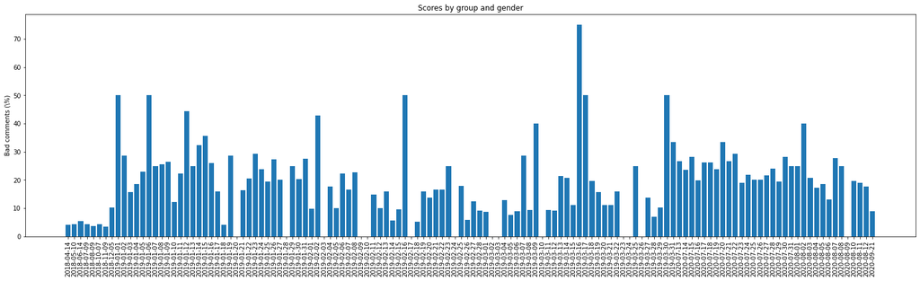

| Satisfaction | Date | processed comment bad | processed comment good | bad_ratio |
| --- | --- | --- | --- | --- |
| 0 | 2018-04-14 | 22.0 | 526.0 | 4.014599 |
| 1 | 2018-05-10 | 33.0 | 735.0 | 4.296875 |
| 2 | 2018-06-14 | 40.0 | 712.0 | 5.319149 |
| 3 | 2018-07-09 | 41.0 | 915.0 | 4.288703 |
| 4 | 2018-08-09 | 20.0 | 529.0 | 3.642987 |
| ... | ... | ... | ... | ... |
| 125 | 2020-08-09 | 0.0 | 10.0 | 0.000000 |
| 126 | 2020-08-10 | 102.0 | 418.0 | 19.615385 |
| 127 | 2020-08-11 | 22.0 | 94.0 | 18.965517 |
| 128 | 2020-08-12 | 3.0 | 14.0 | 17.647059 |
| 129 | 2020-09-21 | 9.0 | 92.0 | 8.910891 |

130 rows × 4 columns

```python
data_responses['Survey Date'] = pd.to_datetime(data_responses['Survey Date'] )
data_responses['Survey Date']
comments_day = data_responses.groupby(['Survey Date','Satisfaction'])[['processed comment']].count().unstack('Satisfaction').reset_index().rename(columns={'Survey Date': 'Date', 'Rating': 'Counts'}).fillna(0)
comments_day['bad_ratio'] = 100 * comments_day.iloc[:, comments_day.columns.get_level_values(1)=='bad'].values/(comments_day.iloc[:, comments_day.columns.get_level_values(1)=='good'].values + comments_day.iloc[:, comments_day.columns.get_level_values(1)=='bad'].values)

fig = plt.figure(figsize=(20,5))
ax = fig.add_axes([0,0,1,1])
#ax.bar(X + 0.00, data[0], color = 'b', width = 0.25)
ax.bar(range(0,130),comments_day['bad_ratio'])
ax.set_ylabel('Bad comments (\%)')
ax.set_title('Scores by group and gender')
ax.set_xticks(range(0,130));
ax.set_xticklabels(comments_day['Date'].dt.date, rotation = 90);
plt.show()
comments_day
```

# Integrate with sales

Now we wanted to evaluate the volume of sales in the virtual store to evaluate any relatioships with the comments

```python
# Load preprocessed data from sales
base_datapath = 'C:\\Users\\sapmn3\\Database\\OFFCORSS\\data\\data_clean'

load_file = 'offcorss_ventas_virtual'
load_path = os.path.join(base_datapath, load_file + '.csv')
data_ventas_tv = pd.read_csv(load_path, thousands=',')
data_ventas_tv.head()
```

|  | Unnamed: 0 | Nro. Pedido | F. Pedido | Población Destinatario | Desc. Material | Vlr. Factura | Colección | Tipo de Referencia | Tipo de Artículo | Concepto Diseño | Source |
| --- | --- | --- | --- | --- | --- | --- | --- | --- | --- | --- | --- |
| 0 | 0 | 66021827 | 14/12/2019 | NaN | CAMISA MANGA CORTA EN TEJIDO PLANO, LLEV | 63.782,00 | 9047.0 | PRENDA EXTERIOR | CAMISA MANGA CORTA | SPECIAL OCCASIONS | tVirtual |
| 1 | 1 | 66021827 | 14/12/2019 | NaN | CAMISA MANGA CORTA EN TEJIDO PLANO, LLEV | 63.782,00 | 9047.0 | PRENDA EXTERIOR | CAMISA MANGA CORTA | SPECIAL OCCASIONS | tVirtual |
| 2 | 2 | 66021827 | 14/12/2019 | NaN | CAMISETA MANGA LARGA EN TEJIDO DE PUNTO | 58.739,00 | 8977.0 | PRENDA EXTERIOR | CAMISETA MANGA LARGA | PLAYA | tVirtual |
| 3 | 3 | 66021827 | 14/12/2019 | NaN | CAMISETA MANGA LARGA EN TEJIDO DE PUNTO | 58.815,00 | 9238.0 | PRENDA EXTERIOR | CAMISETA MANGA LARGA | PLAYA | tVirtual |
| 4 | 4 | 66021827 | 14/12/2019 | NaN | BODY MC EN TEJIDO DE PUNTO | 55.454,00 | 9443.0 | PRENDA EXTERIOR | BODY MANGA CORTA | ROAD TO ALASKA | tVirtual |

```python
#data_ventas_tv['F. Pedido'] = pd.to_datetime(data_ventas_tv['F. Pedido'],  errors='coerce')
data_ventas_tv['F. Pedido'] = pd.to_datetime(data_ventas_tv['F. Pedido'])

data_ventas_tv['F. Pedido'] = data_ventas_tv['F. Pedido'].dt.date
data_ventas_tv['Vlr. Factura'] = data_ventas_tv.iloc[:,:]['Vlr. Factura'].str.replace(',', '').astype(float)
```

```python
data_ventas_tv_agg = data_ventas_tv.copy()
data_ventas_tv_agg =  data_ventas_tv_agg.groupby(['F. Pedido'])['Vlr. Factura'].agg(['sum','count'])
data_ventas_tv_agg
```

| F. Pedido | sum | count |
| --- | --- | --- |
| 2018-07-17 | 134.319 | 2 |
| 2018-08-06 | 0.000 | 6 |
| 2018-12-27 | 0.000 | 4 |
| 2018-12-29 | 0.000 | 10 |
| 2018-12-30 | 148.745 | 222 |
| ... | ... | ... |
| 2019-12-27 | 49815.304 | 2898 |
| 2019-12-28 | 15195.330 | 1279 |
| 2019-12-29 | 24381.017 | 755 |
| 2019-12-30 | 13993.649 | 1546 |
| 2019-12-31 | 4442.017 | 770 |

371 rows × 2 columns

```
[20, 143, 2, 1, 1, 1, 1, 1, 1, 1, 1, 1, 1, 1, 1, 1, 1, 1, 1, 1, 1, 1, 1, 1, 1, 1, 1, 1, 1, 1, 1, 1, 1, 1, 1, 1, 1, 1, 1, 1, 1, 1, 1, 1, 1, 1, 1, 1, 1, 1, 1, 1, 1, 1, 1, 1, 1, 1, 1, 1, 1, 1, 1, 1, 1, 1, 1, 1, 1, 1, 1, 1, 1, 1, 1, 1, 1, 1, 1, 1, 1, 1, 1, 1, 1, 1, 1, 1, 1, 1, 1, 1, 1, 1, 1, 1, 1, 1, 1,…
```

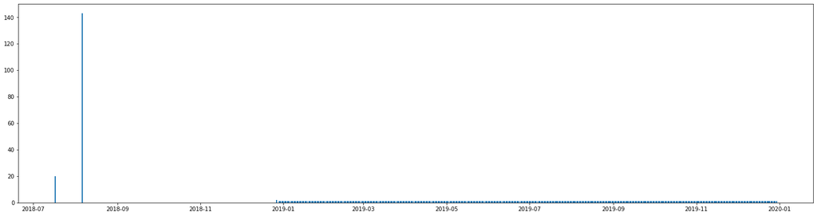

```python
# There are days missing:

comm_day = pd.to_datetime(data_ventas_tv_agg.index[:-1])
distance = list((pd.to_datetime(data_ventas_tv_agg.index[1:]) - pd.to_datetime(data_ventas_tv_agg.index[:-1])).days)
print(distance)

fig = plt.figure(figsize=(20,5))

ax = fig.add_axes([0,0,1,1])
ax.bar(comm_day,distance)
plt.show()
```

We noticed that sales information is also limited and not covering all 2019 and 2020

```python
data_responses['Survey Date'] = pd.to_datetime(data_responses['Survey Date']).dt.date

ls_dates = np.unique(pd.to_datetime(data_responses['Survey Date']).dt.date)
tv_dates = np.unique(data_ventas_tv['F. Pedido'])
dates_in_comments = [date_ for date_ in tv_dates if date_ in ls_dates]
```

```python
data_in_sales = data_responses.copy()
data_in_sales = data_in_sales[data_in_sales['Survey Date'].isin(dates_in_comments)]
data_in_sales
sales_in_data = data_ventas_tv_agg.copy().reset_index()
sales_in_data = sales_in_data[sales_in_data['F. Pedido'].isin(dates_in_comments)]
#data_in_sales.groupby(['Survey Date','Satisfaction'])[['processed comment']].count()
comments_sales = data_in_sales.groupby(['Survey Date','Satisfaction'])[['processed comment']].count().unstack('Satisfaction').reset_index().rename(columns={'Survey Date': 'Date', 'Rating': 'Counts'}).fillna(0)
#comments_day['bad_ratio'] = 100 * comments_day.iloc[:, comments_day.columns.get_level_values(1)=='bad'].values/(comments_day.iloc[:, comments_day.columns.get_level_values(1)=='good'].values + comments_day.iloc[:, comments_day.columns.get_level_values(1)=='bad'].values)

sales_in_data = sales_in_data.rename(columns={"F. Pedido": "Date"})
sales_in_data['Date'] = pd.to_datetime(sales_in_data['Date'])
sales_in_data
```

|  | Date | sum | count |
| --- | --- | --- | --- |
| 6 | 2019-01-01 | 10827.206 | 518 |
| 7 | 2019-01-02 | 13696.252 | 695 |
| 8 | 2019-01-03 | 26300.511 | 1113 |
| 9 | 2019-01-04 | 56142.540 | 2451 |
| 10 | 2019-01-05 | 16620.065 | 609 |
| ... | ... | ... | ... |
| 91 | 2019-03-27 | 26517.646 | 1137 |
| 92 | 2019-03-28 | 26672.365 | 1194 |
| 93 | 2019-03-29 | 30373.387 | 1110 |
| 94 | 2019-03-30 | 26223.871 | 970 |
| 95 | 2019-03-31 | 26411.574 | 1014 |

90 rows × 3 columns

```python
comments_sales
```

| Satisfaction | Date | processed comment bad | processed comment good |
| --- | --- | --- | --- |
| 0 | 2019-01-01 | 2.0 | 2.0 |
| 1 | 2019-01-02 | 16.0 | 40.0 |
| 2 | 2019-01-03 | 25.0 | 134.0 |
| 3 | 2019-01-04 | 8.0 | 35.0 |
| 4 | 2019-01-05 | 8.0 | 27.0 |
| ... | ... | ... | ... |
| 85 | 2019-03-27 | 3.0 | 19.0 |
| 86 | 2019-03-28 | 2.0 | 27.0 |
| 87 | 2019-03-29 | 3.0 | 26.0 |
| 88 | 2019-03-30 | 2.0 | 2.0 |
| 89 | 2019-03-31 | 1.0 | 2.0 |

90 rows × 3 columns

```python
comments_sales['Date'] = pd.to_datetime(comments_sales['Date'])
comments_sales.columns = comments_sales.columns.map(' '.join).str.strip()

comments_sales
```

|  | Date | processed comment bad | processed comment good |
| --- | --- | --- | --- |
| 0 | 2019-01-01 | 2.0 | 2.0 |
| 1 | 2019-01-02 | 16.0 | 40.0 |
| 2 | 2019-01-03 | 25.0 | 134.0 |
| 3 | 2019-01-04 | 8.0 | 35.0 |
| 4 | 2019-01-05 | 8.0 | 27.0 |
| ... | ... | ... | ... |
| 85 | 2019-03-27 | 3.0 | 19.0 |
| 86 | 2019-03-28 | 2.0 | 27.0 |
| 87 | 2019-03-29 | 3.0 | 26.0 |
| 88 | 2019-03-30 | 2.0 | 2.0 |
| 89 | 2019-03-31 | 1.0 | 2.0 |

90 rows × 3 columns

```python
data_join = pd.merge(comments_sales, sales_in_data, how='inner', on=['Date'])
data_join
```

|  | Date | processed comment bad | processed comment good | sum | count |
| --- | --- | --- | --- | --- | --- |
| 0 | 2019-01-01 | 2.0 | 2.0 | 10827.206 | 518 |
| 1 | 2019-01-02 | 16.0 | 40.0 | 13696.252 | 695 |
| 2 | 2019-01-03 | 25.0 | 134.0 | 26300.511 | 1113 |
| 3 | 2019-01-04 | 8.0 | 35.0 | 56142.540 | 2451 |
| 4 | 2019-01-05 | 8.0 | 27.0 | 16620.065 | 609 |
| ... | ... | ... | ... | ... | ... |
| 85 | 2019-03-27 | 3.0 | 19.0 | 26517.646 | 1137 |
| 86 | 2019-03-28 | 2.0 | 27.0 | 26672.365 | 1194 |
| 87 | 2019-03-29 | 3.0 | 26.0 | 30373.387 | 1110 |
| 88 | 2019-03-30 | 2.0 | 2.0 | 26223.871 | 970 |
| 89 | 2019-03-31 | 1.0 | 2.0 | 26411.574 | 1014 |

90 rows × 5 columns

Now we plotted the trends of sales and comments for the dates we have shared data

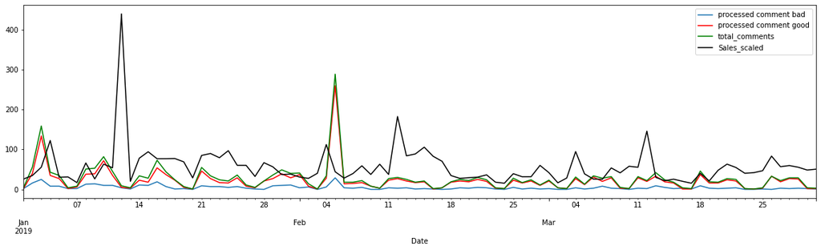

```python
data_join['Sales_scaled'] = data_join['count']/20
data_join['total_comments'] = data_join['processed comment bad'] + data_join['processed comment good']

fig = plt.figure(figsize=(20,5))
ax = plt.gca()

data_join.plot(kind='line',x='Date',y='processed comment bad',ax=ax)
data_join.plot(kind='line',x='Date',y='processed comment good', color='red', ax=ax)
data_join.plot(kind='line',x='Date',y='total_comments', color='green', ax=ax)
data_join.plot(kind='line',x='Date',y='Sales_scaled', color='black', ax=ax)

plt.show()
```

And computed the correlations:

```python
# Correlation
data_join.corr()
```

|  | processed comment bad | processed comment good | sum | count | Sales_scaled | total_comments |
| --- | --- | --- | --- | --- | --- | --- |
| processed comment bad | 1.000000 | 0.813291 | -0.092603 | 0.039249 | 0.039249 | 0.859801 |
| processed comment good | 0.813291 | 1.000000 | 0.021494 | 0.012860 | 0.012860 | 0.996382 |
| sum | -0.092603 | 0.021494 | 1.000000 | 0.242410 | 0.242410 | 0.005336 |
| count | 0.039249 | 0.012860 | 0.242410 | 1.000000 | 1.000000 | 0.017019 |
| Sales_scaled | 0.039249 | 0.012860 | 0.242410 | 1.000000 | 1.000000 | 0.017019 |
| total_comments | 0.859801 | 0.996382 | 0.005336 | 0.017019 | 0.017019 | 1.000000 |

This information tell us that there is no direct correlation between the sales and the comments. However, the comments could be delayed some days after the sales.

Therefore, we checked the **Time Lagged Cross Correlation** to evaluate the temporal dynamics of volume of sales and volume of comments

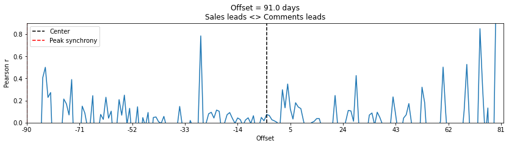

```python
# from https://towardsdatascience.com/four-ways-to-quantify-synchrony-between-time-series-data-b99136c4a9c9
def crosscorr(datax, datay, lag=0, wrap=False):
    """ Lag-N cross correlation.
    Shifted data filled with NaNs

    Parameters
    ----------
    lag : int, default 0
    datax, datay : pandas.Series objects of equal length
    Returns
    ----------
    crosscorr : float
    """
    if wrap:
        shiftedy = datay.shift(lag)
        shiftedy.iloc[:lag] = datay.iloc[-lag:].values
        return datax.corr(shiftedy)
    else:
        return datax.corr(datay.shift(lag))

d1 = data_join['Sales_scaled']
d2 = data_join['total_comments']
months = 3
days = 30
rs = [crosscorr(d1,d2, lag) for lag in range(-int(months*days),int(months*days+1))]
offset = np.ceil(len(rs)/2)-np.argmax(rs)
f,ax=plt.subplots(figsize=(14,3))
ax.plot(rs)
ax.axvline(np.ceil(len(rs)/2),color='k',linestyle='--',label='Center')
ax.axvline(np.argmax(rs),color='r',linestyle='--',label='Peak synchrony')
ax.set(title=f'Offset = {offset} days\nSales leads <> Comments leads',ylim=[.0,.9],xlim=[0,181], xlabel='Offset',ylabel='Pearson r')
ax.set_xticks(list(range(0, 181, 20)))
ax.set_xticklabels(list(range(-90, 90, 19)));
plt.legend()
```